# Python三大程序结构

### 1. 顺序结构

- 程序按照从上到下的顺序依次执行。

### 2. 分支结构

- 使用`if`、`else`架构来进行条件判断和分支执行。

### 3. 循环结构

- `while`和`for`架构用来进行循环操作。

# 函数的定义和调用

### 函数的定义

- 函数是将具有独立功能的代码块组织成一个小模块，使用函数名进行封装，在需要的时候进行调用。
- 使用函数的作用是提高编写效率及代码的重用率。

### 函数的调用

- 定义函数时只给函数一个名称，指定了函数包含的参数和函数体。
- 调用函数意味着执行函数体内的代码，提供函数名和所需的参数即可调用。

### 实参和形参

- **形参**：定义函数时小括号内的参数，用于接收传入的值。
- **实参**：调用函数时小括号内的参数，实际传递给函数的值。

### 函数返回值

- 函数执行结束后，若有`return`语句，则返回结果到函数调用处。

# 变量作用域

### 局部变量

- 定义在函数内部的变量，只在函数执行期间存在。
- 局部变量只在函数内部可见，函数执行完毕后，其值会被销毁。

### 全局变量

- 定义在函数外部的变量，在整个程序中都是可见的。
- 一旦全局变量被定义，它可以在整个程序中被访问和修改。
- 全局变量的作用域是整个程序，其生命周期是程序的整个执行期间。

# 递归

- 递归是函数在其函数体内调用自身的编程技巧。
- 通常用于解决问题规模递减的场景，每次调用时问题变得更小，直到达到基准情况停止递归。

### 1. 顺序结构

- 按照程序的线性顺序依次执行。
- 简单来说，就是从上往下依次执行。

[figure not shown]

```python
# 顺序结构
a = 1
b = 2
print(b)
print(a)
```

```
2
1
```

### 2. 分支结构

- 根据条件的选择来执行不同的代码段。

#### 单分支结构

- **`if`语法格式：**

  ```
  if 表达式:
      语句块
  ```

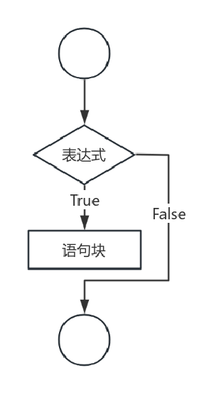

- **执行流程：**
  - 若表达式的值为`True`，则执行语句块。
  - 若表达式的值为`False`，则跳过语句块，执行后面的代码。

#### 多分支结构

- **`if`语法格式：**

  ```
  if 表达式1:
      语句块1
  elif 表达式2:
      语句块2
  elif 表达式3:
      语句块3
  else:
      语句块4
  ```

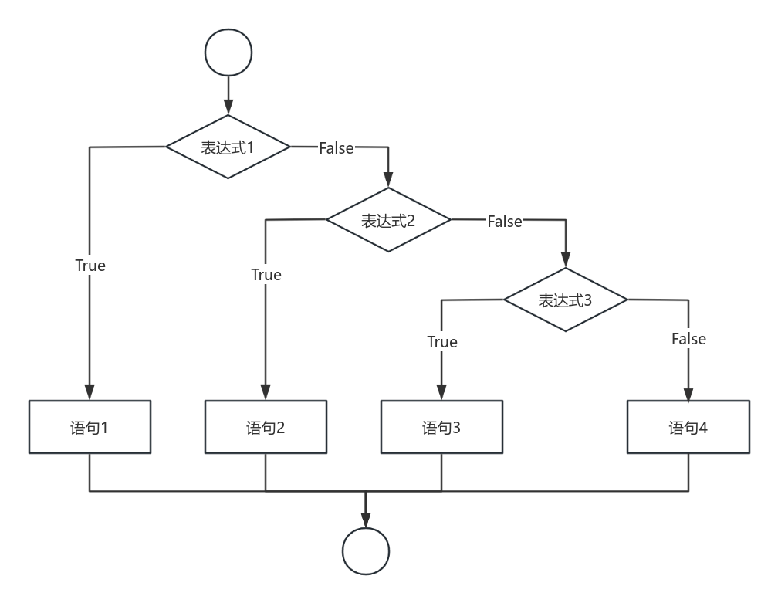

```python
# 单分支结构
a = -1
if a>0:
    print(a)

b = 2
print(b)
```

```
2
```

```python
# 双分支结构
a = -1
if a>=0:
    print("a为非负数")
else:
    print("a为负数")
```

```
a为负数
```

```python
# and 当两个表达式或多个表达式都为真 整体才为真    or 表达式中有一个为真则全为真，只有全为假表达式才为假  not 取反
```

```python
a = 100
b = 10
print(a>90 and b>50) #  a>90 True  b>50 为False
```

```
False
```

```python
a = 100
b = 10
print(a<90 or b>50) #  a<90 为False  b>50 为False
```

```
False
```

```python
a = 100
b = 10
print(a<90 or b<50)  # a<90 为False  b<50 为True
```

```
True
```

```python
# not
a = 1
not(a > 0)
```

```
False
```

```python
# 多分支结构
score = int(input("请输入成绩："))
if score > 100 or score < 0:
    print("输入的成绩有误，请重新输入：")
elif score>=90 and score <= 100:
    print("该学生的成绩为A等，非常不错")
elif score>=80 and score<90:
    print("该学生成绩为B等，也很棒了")
elif score>=70 and score<80:
    print("该学生成绩为C等，还需要努力")
elif score>=60 and score<70:
    print("该学生成绩为D等，要加把劲了，不然就要挂科了")
else:
    print("成绩不及格，准备准备补考吧")
```

```
成绩不及格，准备准备补考吧
```

```python
# if else 嵌套
age = 17
money = 8
if age >= 18:
    print("已经成年，可以进入网吧啦~~")
    if money>=10:
        print("身上的金钱也是充足的，可以愉快的打游戏了~~")
    else:
        print("虽然我满了18岁，但是钱不够上不了网，难受呀")
else:
    print("未成年，不允许上网")
```

```
未成年，不允许上网
```

### 3. 循环结构

#### `while`循环

- **`while`语法格式：**

  ```
  while 判断语句:
      执行语句
  ```

- **例子：**

  ```
  a = 0
  while a < 10:
      print(a)
      a += 1
  ```

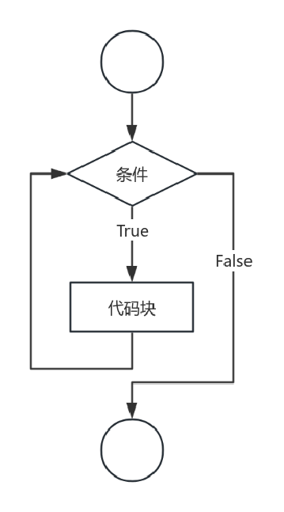

```python
a = 0 # 初始的赋值变量  判断语句  程序执行的代码体  可迭代的变量
while a <= 10:
    print(a)
    a += 1 # a= a+1
```

```
0
1
2
3
4
5
6
7
8
9
10
```

```python
# 1-100 的和
i=0
sum = 0
while i <= 100:
    sum = sum+i
    i += 1
print(sum)
```

```
5050
```

```python
# 求1-100偶数和
i=0
sum = 0
while i <= 100:
    sum = sum+i
    i += 2
print(sum)
```

```
2550
```

```python
# 求1-100偶数和
i=0
sum = 0
while i <= 100:
    if i%2 == 0: # i对2取余，余数为0则满足
        sum = sum+i
    i += 1
print(sum)
```

```
2550
```

```python
# 1-100奇数和
i=1
sum = 0
while i <= 100:
    sum = sum+i
    i += 2
print(sum)
```

```
2500
```

```python
# 打印九九乘法表
i = 1
while(i<10):
    j = 1
    while(j<i+1):
        print(f"{i}*{j}={i*j}",end="\t") # \t为制表符
        j = j+1
    print() # 代表换行 end="\n"
    i = i+1
```

```
1*1=1
2*1=2	2*2=4
3*1=3	3*2=6	3*3=9
4*1=4	4*2=8	4*3=12	4*4=16
5*1=5	5*2=10	5*3=15	5*4=20	5*5=25
6*1=6	6*2=12	6*3=18	6*4=24	6*5=30	6*6=36
7*1=7	7*2=14	7*3=21	7*4=28	7*5=35	7*6=42	7*7=49
8*1=8	8*2=16	8*3=24	8*4=32	8*5=40	8*6=48	8*7=56	8*8=64
9*1=9	9*2=18	9*3=27	9*4=36	9*5=45	9*6=54	9*7=63	9*8=72	9*9=81
```

```python
# *
# * *
# * * *
# * * * *
# * * * * *
```

```python
print("*")
print("* * ")
```

[output not shown]

```python
# 使用while打印*
i = 1
while(i<=5):
    print("* "*i)
    i = i+1
```

[output not shown]

```python
while True:  # 进入无限循环，直到输入有效成绩并打印结果
    score = int(input("请输出学生的成绩："))  # 提示用户输入成绩，将输入的字符串转为整数类型
    # 检查输入的成绩是否在0到100之间
    if score < 0 or score > 100:  # 如果成绩小于0或大于100，说明成绩无效
        print("请输入一个有效的成绩（0-100）！")  # 提示用户输入有效成绩
        continue  # 如果输入无效，跳过当前循环，重新要求输入成绩
    # 如果成绩有效，进入各个等级的判断
    if score <= 100 and score >= 90:  # 如果成绩大于等于90并且小于100
        print("该学生的成绩为A等，非常不错！")  # 输出A等成绩评价
    elif score < 90 and score >= 80:  # 如果成绩大于等于80并且小于90
        print("该学生的成绩为B等，也很棒了")  # 输出B等成绩评价
    elif score < 80 and score >= 70:  # 如果成绩大于等于70并且小于80
        print("该学生的成绩C等，努努力再冲一冲")  # 输出C等成绩评价
    elif score < 70 and score >= 60:  # 如果成绩大于等于60并且小于70
        print("该学生的成绩为D等，赶紧加劲学习！")  # 输出D等成绩评价
    else:  # 如果成绩小于60
        print("成绩不及格，准备准备补考吧")  # 输出不及格成绩评价
    # 如果输入有效成绩后，退出循环
    break  # 结束循环，程序执行完毕
```

```
请输入一个有效的成绩（0-100）！
请输入一个有效的成绩（0-100）！
请输入一个有效的成绩（0-100）！
该学生的成绩为D等，赶紧加劲学习！
```

#### `for`循环

- **`for`语法格式：**

  ```
  for 变量名 in 可迭代对象:
      语句块
  ```

- **例子：**

  ```
  for i in range(10):
      print(i)
  ```

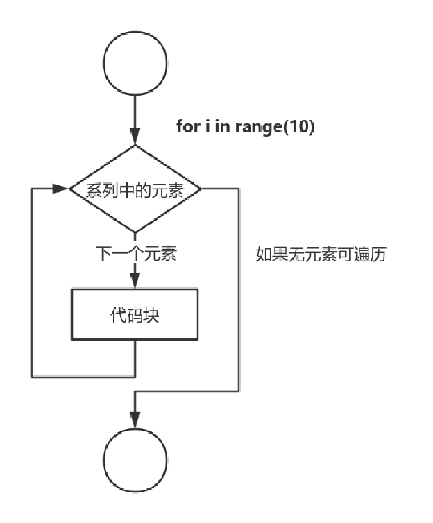

```python
# for 循环
for c in range(10): # range start 0 end 10 step 1 左闭右开 [0,10)
    print(c+1)
```

```
1
2
3
4
5
6
7
8
9
10
```

```python
# for 循环打印九九乘法表
for i in range(1,10):
    for j in range(1,i+1):
        print(f"{i}*{j}={i*j}",end="\t")
    print()
```

```
1*1=1
2*1=2	2*2=4
3*1=3	3*2=6	3*3=9
4*1=4	4*2=8	4*3=12	4*4=16
5*1=5	5*2=10	5*3=15	5*4=20	5*5=25
6*1=6	6*2=12	6*3=18	6*4=24	6*5=30	6*6=36
7*1=7	7*2=14	7*3=21	7*4=28	7*5=35	7*6=42	7*7=49
8*1=8	8*2=16	8*3=24	8*4=32	8*5=40	8*6=48	8*7=56	8*8=64
9*1=9	9*2=18	9*3=27	9*4=36	9*5=45	9*6=54	9*7=63	9*8=72	9*9=81
```

### 函数

函数是把具有独立功能的代码块组织成一个小模块，使用函数名进行封装，在需要的时候进行调用。

使用函数的作用在于，当我们进行开发工作时，使用函数可以提高编写的效率以及代码的重用率。

#### 内置函数：

- `print()`
- `input()`

#### 自定义函数：

```
def 函数名(参数):
    函数体
    return [表达式]
```

#### 示例：

```
def add(a, b):
    result = a + b
    return result
```

```python
# 函数
def add(a,b): # 函数的定义 a b 为形参
    reslut = a+b
    return reslut # 若无return 返回值默认为None
```

### 函数调用

定义函数时，只给函数一个名称，并指定函数包含的参数和函数体。调用函数意味着执行函数体内的代码。调用时，需要提供函数名和所需的参数。

### 函数实参和形参

- **形参**：定义函数时小括号内的参数，用来接收传入的值。
- **实参**：调用函数时小括号内的参数，用来传递给函数使用。

### 函数返回值

函数执行结束后，如果有 `return` 语句，则会返回结果给函数调用处。

#### 示例：

```
sum = add(1, 2)
print(sum)
```

```python
sum = add(5,2) # 1 2为实参
sum
```

```
7
```

```python
# 匿名函数  函数名 = lambda 参数 表达式
fun = lambda a,b:a+b
fun(5,2)
```

```
7
```

### 局部变量

局部变量是定义在函数内部的变量，它只在函数执行期间存在。局部变量只在函数内部可见，当函数执行完毕后，它的值会被销毁。

### 全局变量

全局变量是定义在函数外部的变量，它在整个程序中都是可见的。一旦全局变量被定义，它就可以在整个程序中被访问和修改。

全局变量的作用域是整个程序，它的生命周期也是整个程序的执行期间。

#### 示例：

```
a = 100

def test():
    a = 10
    print(a)

test()
print(a)
```

```python
# 局部变量 全局变量
a = 100
def test():
    a = 10
    a = 8
    print(a)

test() # 就近原则
print(a)
```

```
8
100
```

### 递归

递归是指在一个函数的函数体内调用该函数本身，该函数就是递归函数。

### 递归特性

- **递归必须有明确的结束条件**。
- **每进入更深一层的递归时，问题规模应该比上次递归要有所减少**。
- **递归效率不高，递归层次过多会导致栈溢出**。  
  （在计算机中，函数调用是通过栈（stack）这种数据结构实现的。每当进入一个函数调用，栈就会加一层栈帧；每当函数返回，栈就会减一层栈帧。由于栈的大小是有限的，递归调用次数过多会导致栈溢出。）

### 案例：使用递归计算n的阶乘

```python
# n! = n *（n-1）* ... * 1   5! = 5*4*3*2*1 =120
def fun(n):
    if n == 1:
        return 1
    else:
        return n*fun(n-1)

fun(5)
```

```
120
```

### 水仙花数

水仙花数指的是一个三位数，它的各个位上的数字的立方和等于它本身。例如153就是一个水仙花数：

[ 153 = 1^3 + 5^3 + 3^3 ]

### 案例：使用循环求出1000以内的水仙花数

```python
# 求解水仙花数 100-1000 153 = 1^3+5^3+3^3
for i in range(100,1000):
    a = i//100 # 百分位
    b = i//10%10 # 十分位
    c = i%10 # 个分位
    if i == a**3 + b**3 +c**3:
        print(f"该数为水仙花数，数值为{i}")
```

```
该数为水仙花数，数值为153
该数为水仙花数，数值为370
该数为水仙花数，数值为371
该数为水仙花数，数值为407
```

```python
a = 153
a%10
```

```
3
```